# M05-06 - Artrite Reumatóide

Pietro Garmatter

2024-09-25

```r
library(fpp3)
library(tidyverse)
library(RPostgres)
library(DBI)
library(GGally)
library(ggdist)
library(ggfortify)
library(MASS)
library(splines)
library(patchwork)
library(distributional)

setwd("E:/GEATS/Estimador-AIO-SUS/M05-06/")
load("M05-06.RData")

if(exists("meds.bkp")){
  meds <- meds.bkp
}

select <- dplyr::select
```

# Exploratória Soma

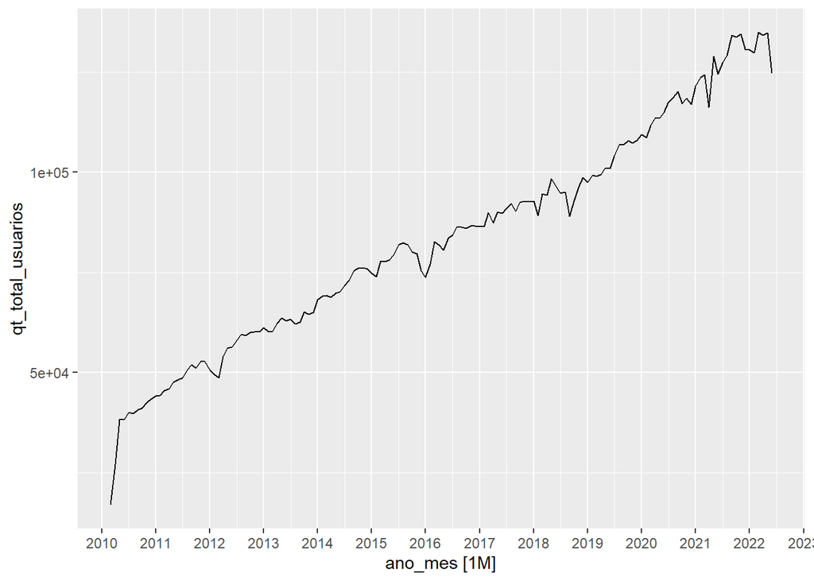

```r
autoplot(soma, qt_total_usuarios) +
  scale_x_yearmonth(date_breaks = '1 year', date_labels='%Y')
```

```r
mean(soma$qt_total_usuarios)
```

```
## [1] 83292.02
```

```r
var(soma$qt_total_usuarios)
```

```
## [1] 749314518
```

Apesar de bastantes observações, média e variância diferentes. É possível fazer análises, mas não utilizar Poisson no GLM (superdispersão).

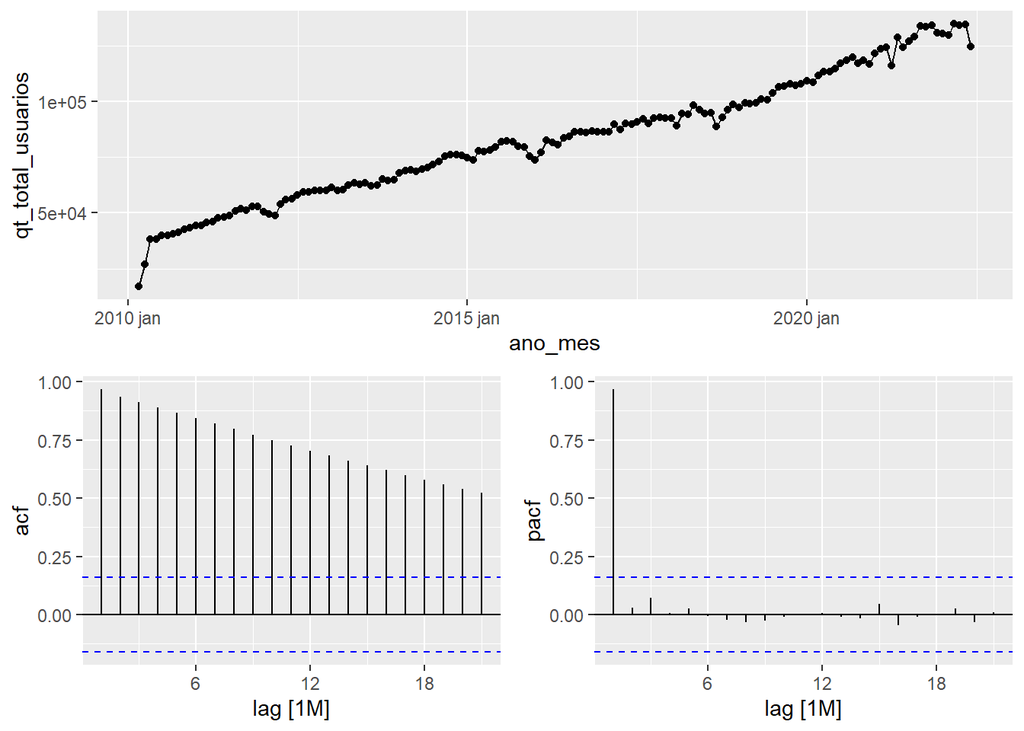

```r
gg_tsdisplay(soma, y = qt_total_usuarios, plot_type = "partial")
```

FAC e FACP sugerem processo AR(1). Série diferenciada bastante estacionária, certa variância maior perto do final.

```r
(lb12 = format(ljung_box(soma$qt_total_usuarios, lag = 12)["lb_pvalue"], nsmall = 4))
```

```
## lb_pvalue
##  "0.0000"
```

```r
(lb24 = format(ljung_box(soma$qt_total_usuarios, lag = 24)["lb_pvalue"], nsmall = 4))
```

```
## lb_pvalue
##  "0.0000"
```

Os testes de Ljung-Box para 12 e 24 meses rejeita a hipótese nula de que a série seja ruído branco com valores de p iguais a 0.0000 e 0.0000.

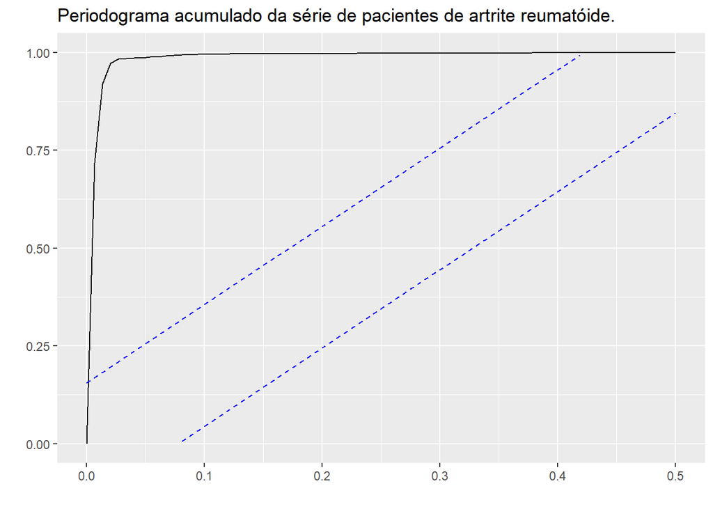

```r
ggcpgram(soma$qt_total_usuarios) +
  labs(title = 'Periodograma acumulado da série de pacientes de artrite reumatóide.')
```

Tudo indica que a soma pode ser modelada.

# Modelagem Soma

Modelo proposto ARIMA(1,1,0) com drift e sem sazonalidade.

```r
soma.treino <- soma %>% filter(ano_mes < yearmonth("2020/06"))

models <- soma.treino %>%
  model(A = ARIMA(qt_total_usuarios ~ 1 + pdq(1,1,0) + PDQ(0,0,0)),
        B = ARIMA(qt_total_usuarios),
        C = ETS(qt_total_usuarios ~ error("A") + trend("A") + season("N")),
        D = ETS(qt_total_usuarios ~ error("M") + trend("A") + season("N")),
        E = TSLM(qt_total_usuarios ~ ano_mes))

quasipoisson = glm(qt_total_usuarios ~ ano_mes, soma.treino, family = quasipoisson())

binomialneg = glm.nb(qt_total_usuarios ~ ano_mes, soma.treino)
nb.label = "F"

glance(models) %>%
  select(.model, AIC) %>%
  bind_rows(data.frame(.model = c('quasipoisson', nb.label), AIC = c(NA, AIC(binomialneg))))
```

```
## # A tibble: 7 × 2
##   .model         AIC
##   <chr>        <dbl>
## 1 A            2229.
## 2 B            2225.
## 3 C            2497.
## 4 D            2659.
## 5 E            2006.
## 6 quasipoisson   NA
## 7 F            2545.
```

O modelo E (TSLM em função do tempo) teve o melhor AIC entre os modelos ajustados (2006.070). Os modelos ARIMA(1,1,0) com drift (A) e ARIMA(0,1,0)(1,0,0)[12] com drift (B) seguiram com AICs 2228.534 e 2225.077, respectivamente.

# Análise de resíduos (soma)

```r
newdata = soma %>% filter(ano_mes >= yearmonth("2020/06"))

cast <- models %>%
  forecast(new_data = newdata)

nb.cast = predict.glm(binomialneg, newdata, type="response")
nb.mean = nb.cast #uma por mes
nb.var = var(soma$qt_total_usuarios) #var da serie ou da série predita? NESSE CASO USEI DA SERIE POIS ESTAVA DANDO P>1

size = nb.mean^2 /(nb.var - nb.mean)
prob = nb.mean / nb.var

nb.cast = fable(.model = nb.label,
                ano_mes = unique(cast$ano_mes),
                qt_total_usuarios = dist_negative_binomial(size, prob),
                mean = nb.cast,
                d1 = c(NA, diff(nb.cast)),
                response = 'qt_total_usuarios',
                distribution = 'qt_total_usuarios')
```

```
## Using `ano_mes` as index variable.
```

```r
cast <- cast %>%
  bind_rows(nb.cast)

cast %>%
  accuracy(soma,
           list(REQM = RMSE,
                winkler = winkler_score), level = 95)
```

```
## # A tibble: 6 × 4
##   .model .type  REQM winkler
##   <chr>  <chr> <dbl>   <dbl>
## 1 A      Test  4068.  32082.
## 2 B      Test  3689.  30687.
## 3 C      Test  3728.  52004.
## 4 D      Test  3715.  68659.
## 5 E      Test  8338.  86138.
## 6 F      Test  9622. 106910.
```

Contrário do que o AIC sugeriu, o modelo E não teve boa predição da média, com REQM 8337.775. Os ARIMAs A e B, por outro lado, tiveram REQMs menores que a metade do avaliado para E (4068.019 e 3689.494), sendo B o modelo com o REQM mais baixo de todos os modelos avaliados. Quanto aos escores, os modelos ARIMA ficaram com os melhores resultados, sendo o escore de A 32082.25, e de B 30686.95. Sendo assim, tudo indica que o melhor modelo para a predição da demanda total por tratamento com medicamentos do CEAF 1A no SUS seja o modelo B (ARIMA(0,1,0)(1,0,0)[12] com drift)

# Análise dos gráficos Soma

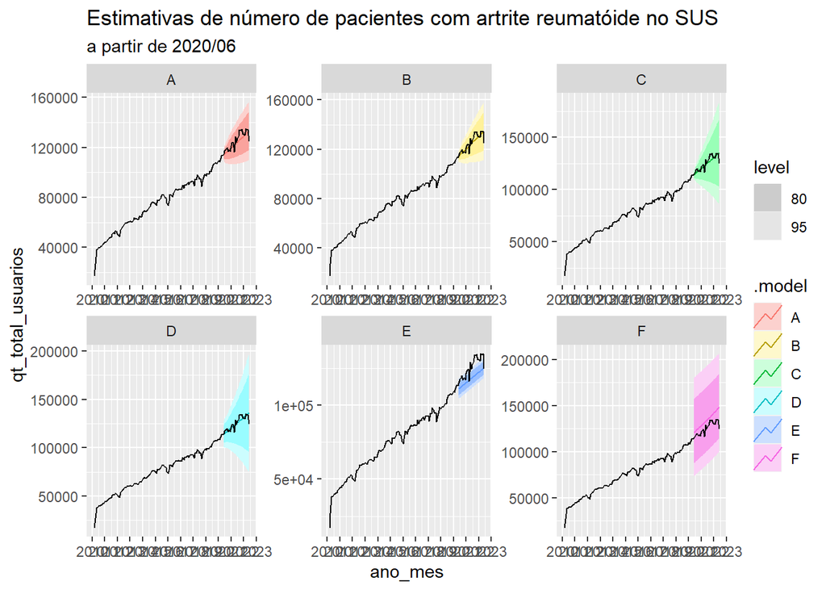

```r
cast %>%
  autoplot(soma) +
  facet_wrap(~ .model, scales = "free") +
  scale_x_yearmonth(date_breaks = '1 years', date_labels='%Y') +
  labs(title = "Estimativas de número de pacientes com artrite reumatóide no SUS",
       subtitle = "a partir de 2020/06")
```

A análise dos gráficos corrobora a conclusão de que o modelo B seja o melhor candidato entre os modelos ajustados, podendo ser utilizado também o modelo proposto A.

# Análises de medicamentos

```r
tratamentos %>%
  select(no_identificador, via, linha_tto, doses_inducao, periodicidade_min, periodicidade_max, somente_contraindicacao) %>%
  unique()
```

```
##    no_identificador         via linha_tto doses_inducao periodicidade_min
## 1         ABAT60432  subcutaneo         3             0                 7
## 2         ABAT60432 intravenoso         3             3                28
## 3         ADAL60438  subcutaneo         3             0                14
## 8     BAMGPOCO60432        oral         3             0                 1
## 9         CERT60438  subcutaneo         3             3                14
## 10        ETAN60438  subcutaneo         3             0                 7
## 13        GOLI60438  subcutaneo         3             0                28
## 14        INFL60438 intravenoso         3             3                56
## 16        LEFL60432        oral         1             0                 1
## 17        METO60453 intravenoso         1             0                 7
## 18        METO60453        oral         1             0                 1
## 19        RITU60468 intravenoso         3             2               180
## 21        TOCI60469 intravenoso         3             0                28
## 22        CITR60432        oral         3             0               0.5
##    periodicidade_max somente_contraindicacao
## 1                  7                       0
## 2                 28                       0
## 3                 14                       0
## 8                  1                       0
## 9                 28                       0
## 10                 7                       0
## 13                28                       0
## 14                56                       0
## 16                 1                       0
## 17                 7                       0
## 18                 1                       0
## 19               365                       1
## 21                28                       0
## 22               0.5                       0
```

```r
meds <- meds %>%
  mutate(key = paste(no_identificador, via, sep = '_')) %>%
  as_tsibble(key = key, index = ano_mes)
```

Como a abordagem de modelagem da diferenciada da tendência não foi satisfatória para M45, o método não foi reproduzido para outros PCDTs. Segue-se para as outras análises.

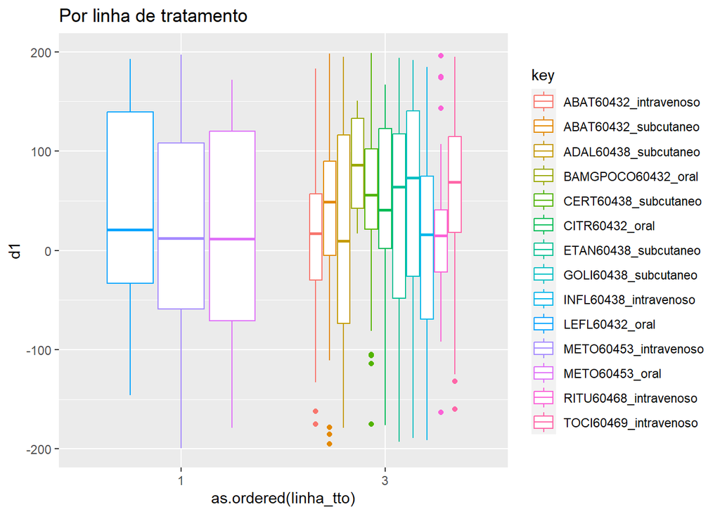

```r
# removendo diferenças maiores que +-200, pois são outliers e dificultam a visualização do restante.
meds <- meds %>% mutate(d1 = difference(qt_usuarios))

meds %>%
  filter(d1 > -200 & d1 < 200) %>%
  ggplot(aes(x = as.ordered(linha_tto), y = d1, colour = key)) +
  geom_boxplot() +
  labs(title = "Por linha de tratamento")
```

A mediana da taxa de crescimento parece ter maior variância entre os medicamentos da terceira linha que entre os da primeira. As maiores taxas medianas observadas também estão na terceira linha.

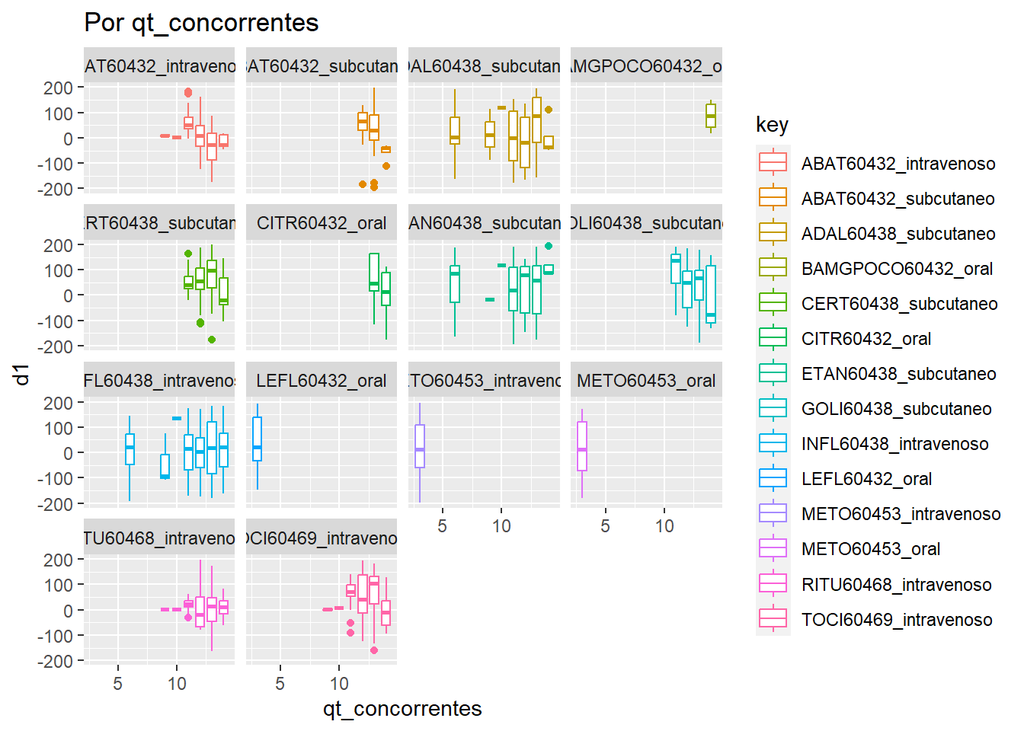

```r
meds %>%
  filter(d1 > -200 & d1 < 200) %>%
  ggplot(aes(x = qt_concorrentes, y = d1, colour = key, group = interaction(key, qt_concorrentes))) +
  geom_boxplot() +
  facet_wrap(~key) +
  labs(title = "Por qt_concorrentes")
```

AAlguns medicamentos parecem ter maior crescimento quando em presença de competidores, enquanto outros passam a perder pacientes quanto mais medicamentos são incorporados. Em especial, esse comportamento se observa em maior intensidade na incorporação de baricitinibe, o que diminuiu a taxa de crescimento de golimumabe, adalimumabe, certolizumabe pegol, abatacepte e tocilizumabe.

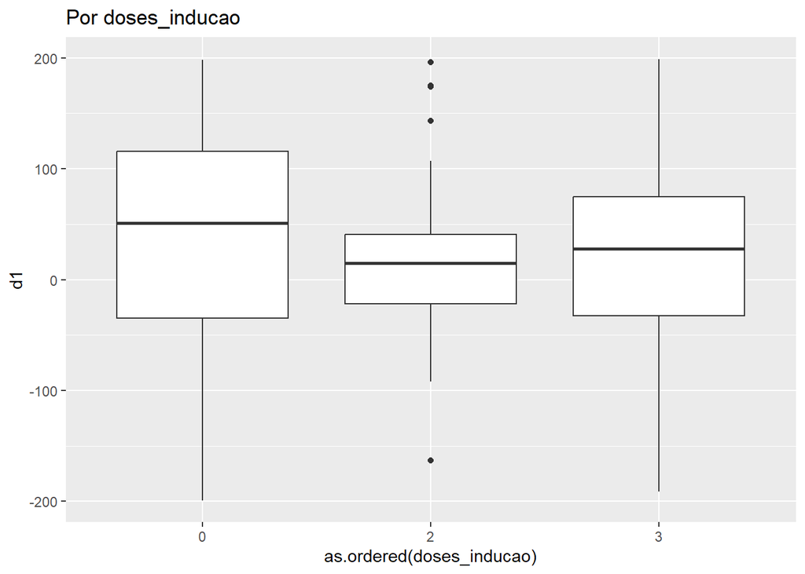

```r
meds %>%
  filter(d1 > -200 & d1 < 200) %>%
  ggplot(aes(x = as.ordered(doses_inducao), y = d1)) +
  geom_boxplot() +
  labs(title = "Por doses_inducao")
```

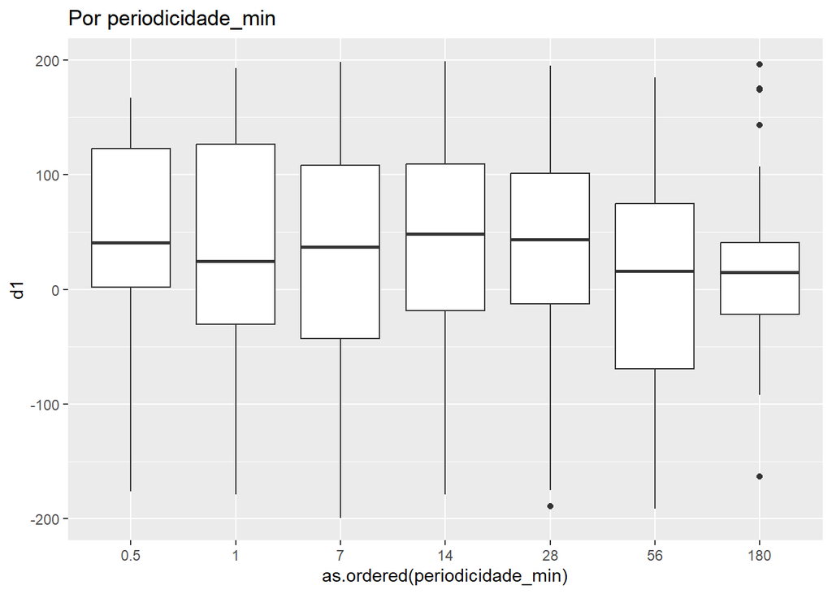

```r
meds %>%
  filter(d1 > -200 & d1 < 200) %>%
  ggplot(aes(x = as.ordered(periodicidade_min), y = d1)) +
  geom_boxplot() +
  labs(title = "Por periodicidade_min")
```

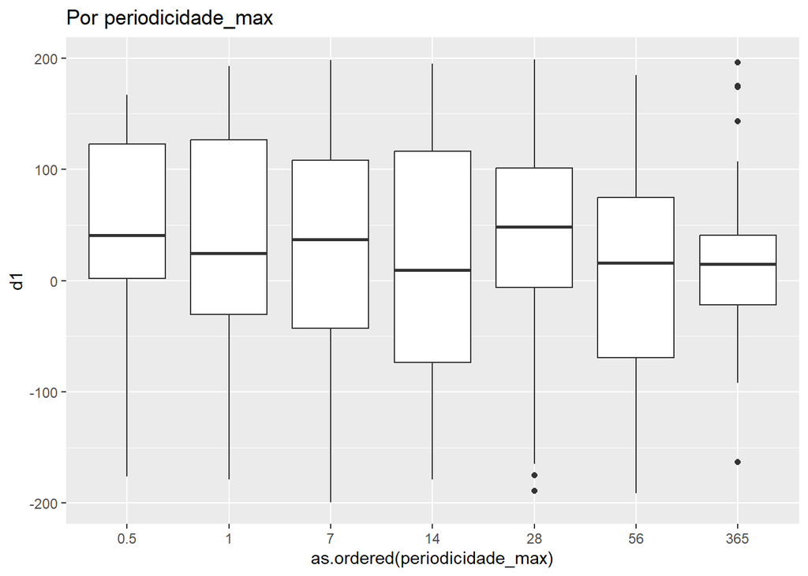

```r
meds %>%
  filter(d1 > -200 & d1 < 200) %>%
  ggplot(aes(x = as.ordered(periodicidade_max), y = d1)) +
  geom_boxplot() +
  labs(title = "Por periodicidade_max")
```

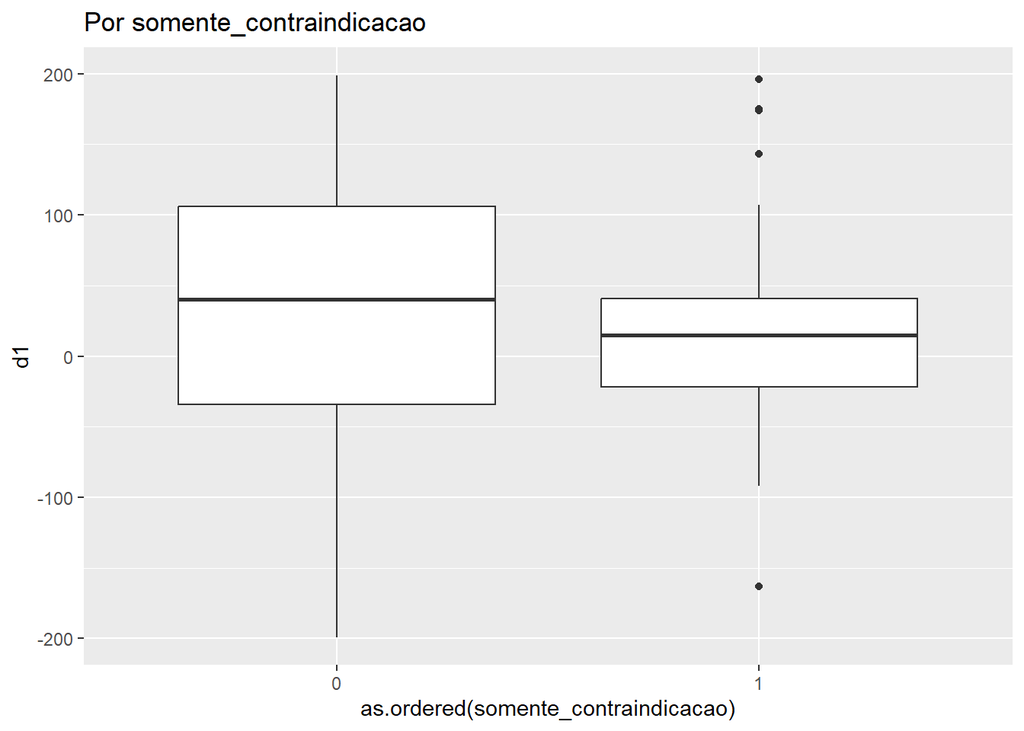

```r
meds %>%
  filter(d1 > -200 & d1 < 200) %>%
  ggplot(aes(x = as.ordered(somente_contraindicacao), y = d1)) +
  geom_boxplot() +
  labs(title = "Por somente_contraindicacao")
```

Nenhuma das características definidas acima parecem ter relação linear com a taxa de crescimento no número de pacientes. A variável somente_contraindicacao, que se refere a contraindicação absoluta a qualquer outro imunobiológico que não seja rituximabe, só é verdadeira para este medicamento. Rituximabe tem uma mediana de crescimento menor que a mediana geral dos outros medicamentos.

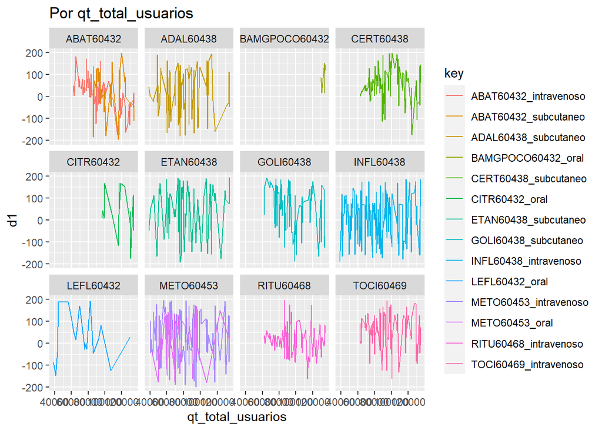

```r
meds %>%
  filter(d1 > -200 & d1 < 200) %>%
  ggplot(aes(x = qt_total_usuarios, y = d1, colour = key)) +
  geom_line() +
  labs(title = "Por qt_total_usuarios") +
  facet_wrap(~no_identificador)
```

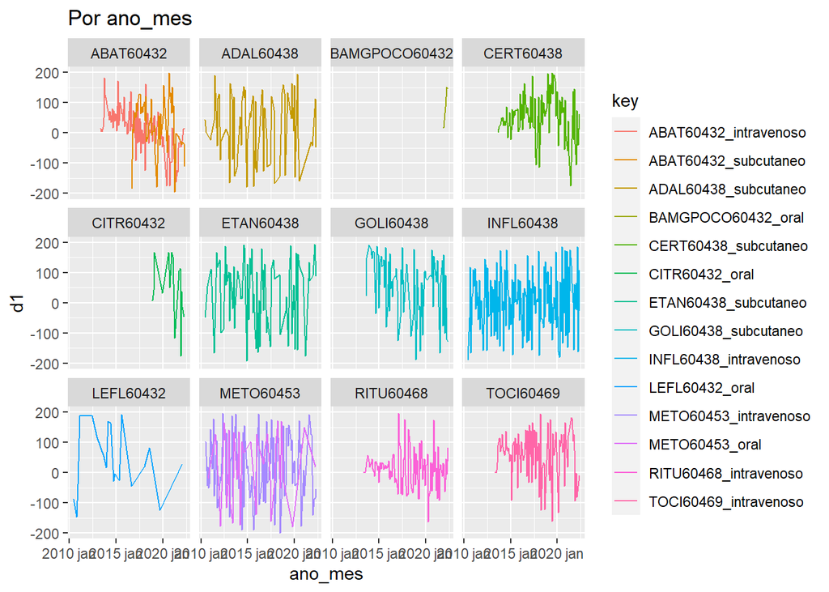

```r
meds %>%
  filter(d1 > -200 & d1 < 200) %>%
  ggplot(aes(x = ano_mes, y = d1, colour = key)) +
  geom_line() +
  labs(title = "Por ano_mes") +
  facet_wrap(~no_identificador)
```

Finalmente, as séries diferenciadas parecem razoavelmente estacionárias na média com o aumento no número total de pacientes, bem como com o passar do tempo (altamente correlacionado com o número de pacientes total), salvo abatacepte e certolizumabe pegol, que tendem a diminuir com o tempo. Não parece haver uma diferença considerável na variância com o decorrer do tempo para os outros medicamentos.

## Seguindo com a modelagem dos medicamentos

```r
for(i in unique(meds$key)) {
  print((meds %>%
           filter(key == i) %>%
           as_tibble() %>%
           select(qt_usuarios))$qt_usuarios %>%
          ggcpgram() +
          labs(title = paste("Periodograma acumulado", i)))
}
```

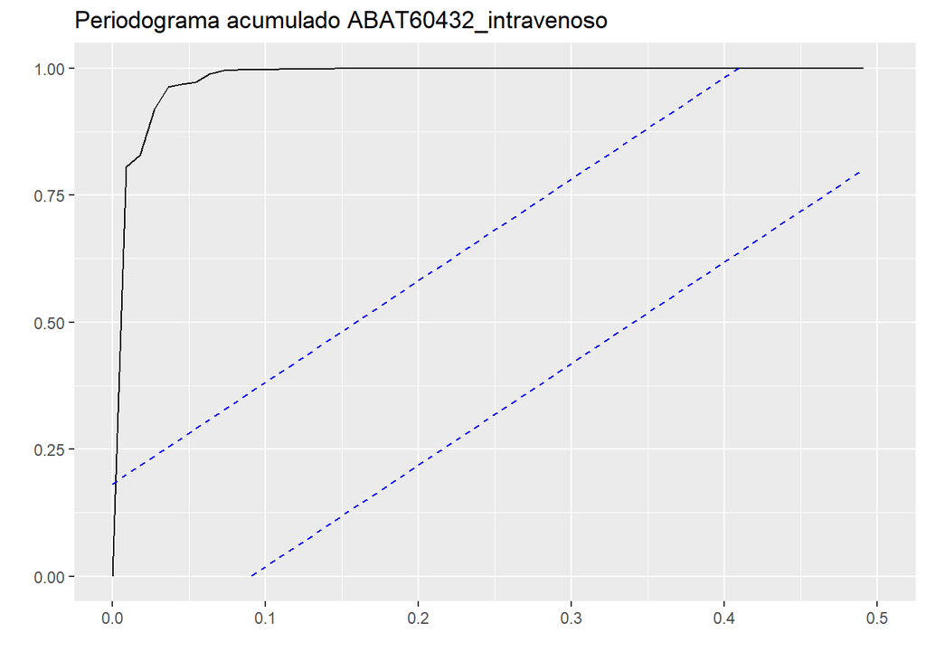

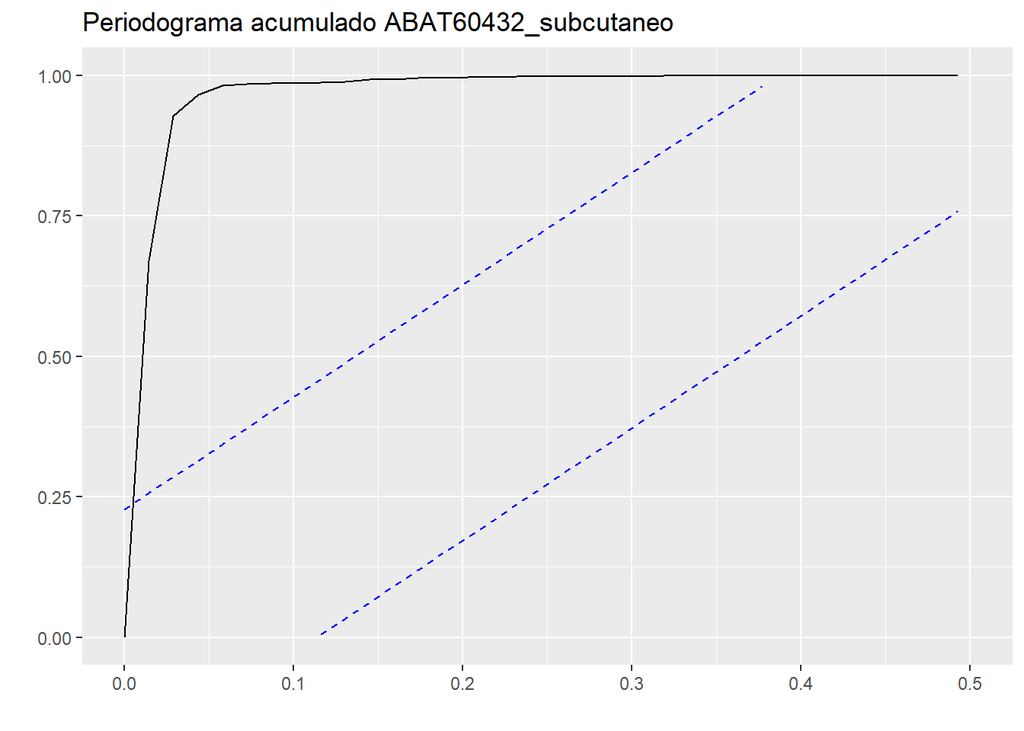

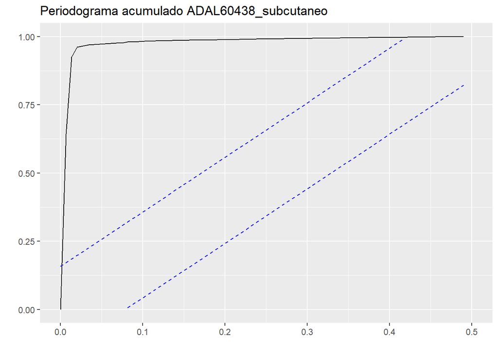

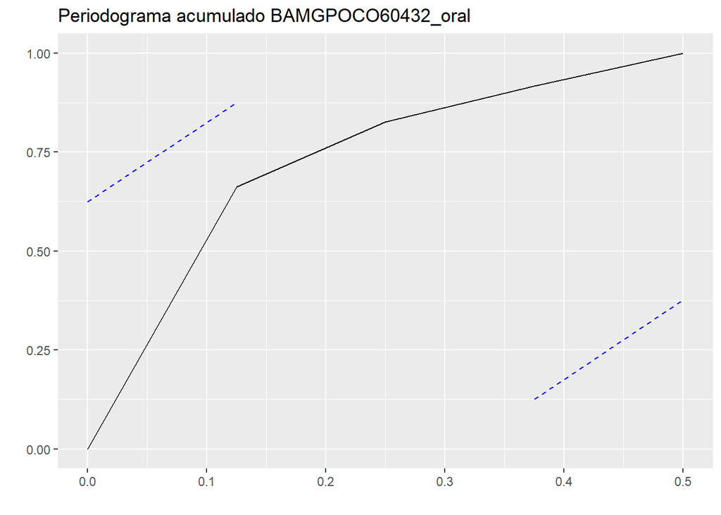

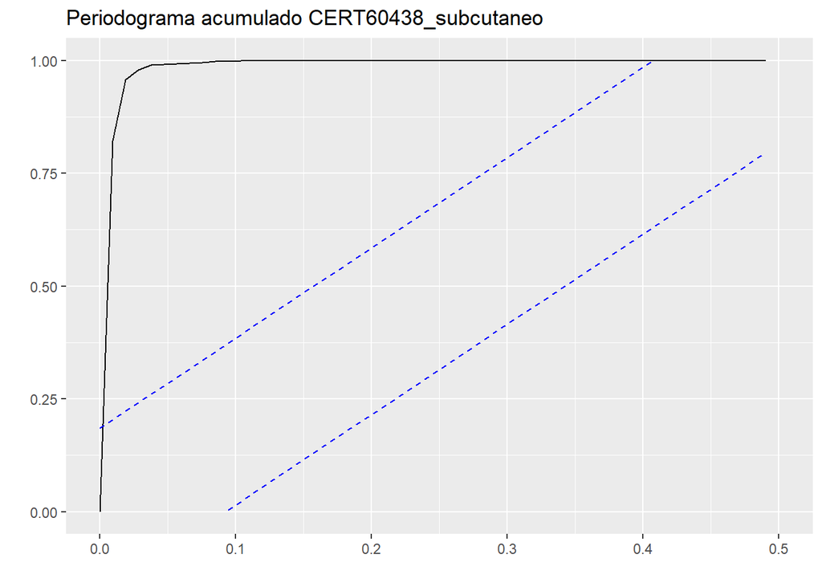

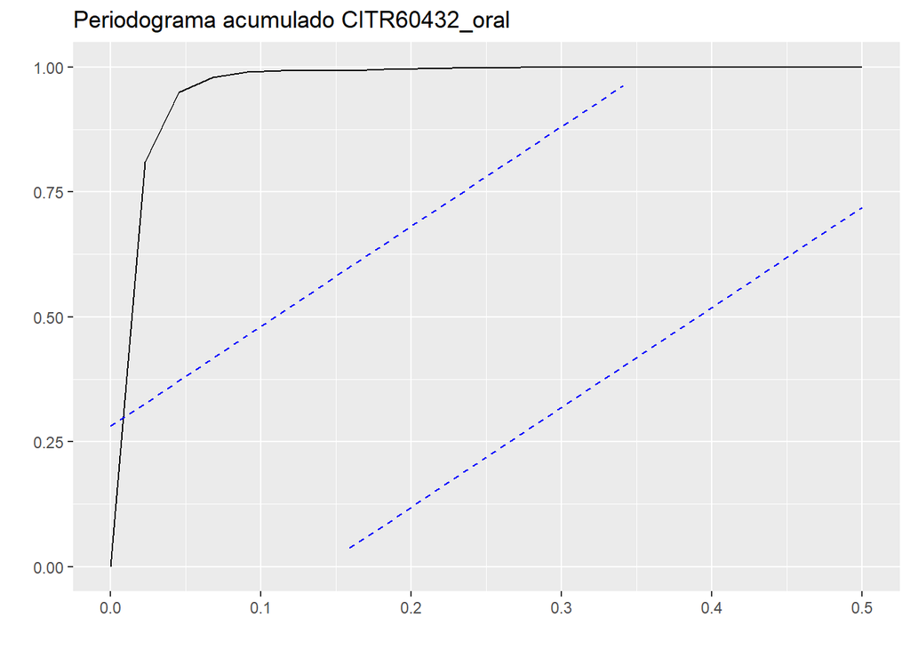

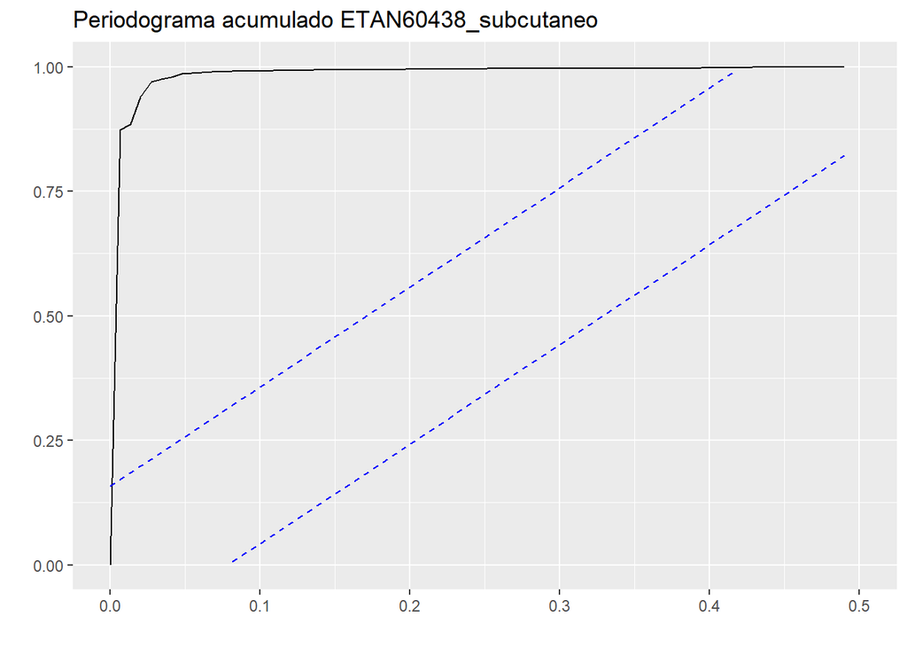

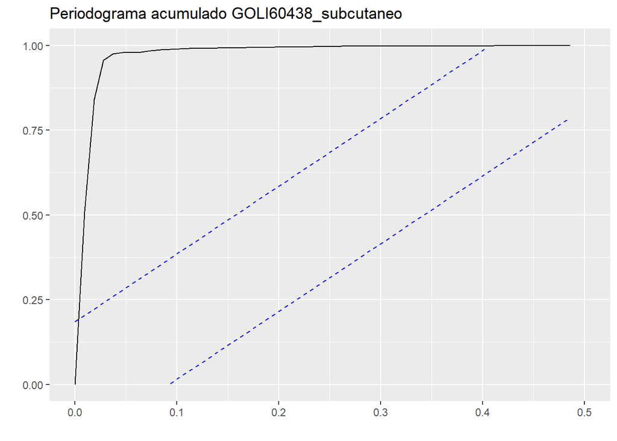

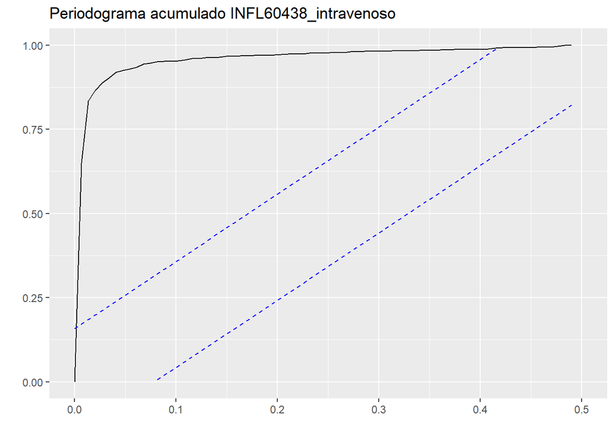

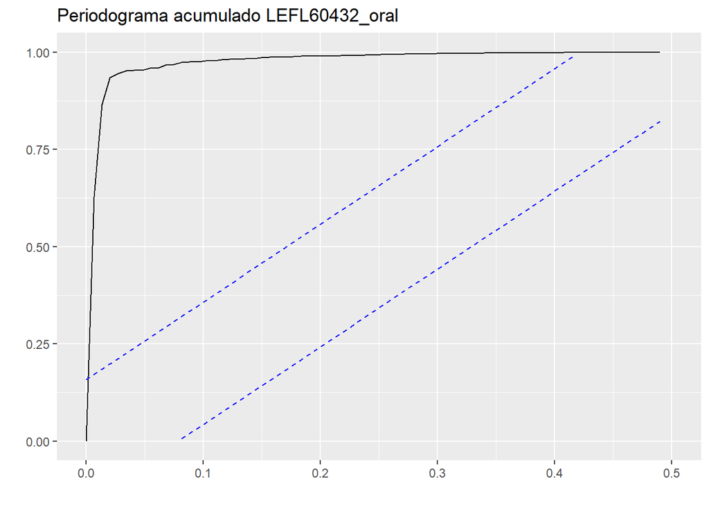

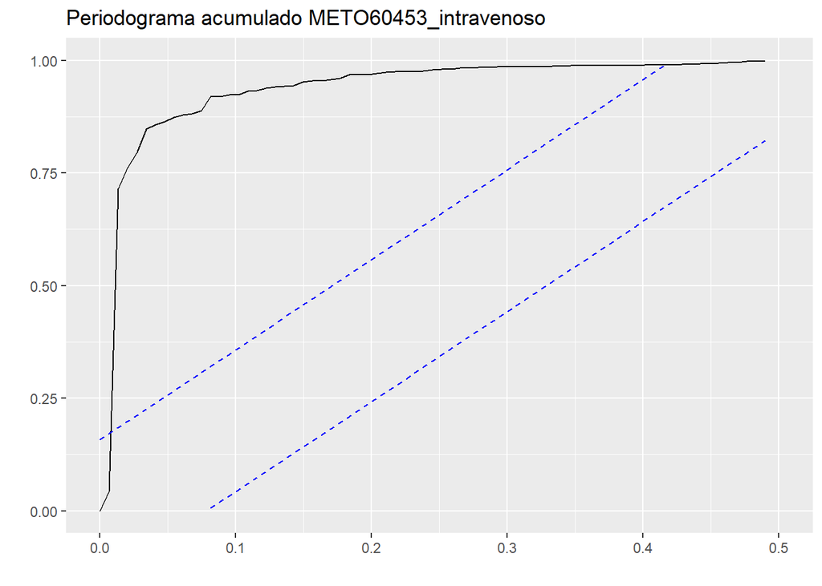

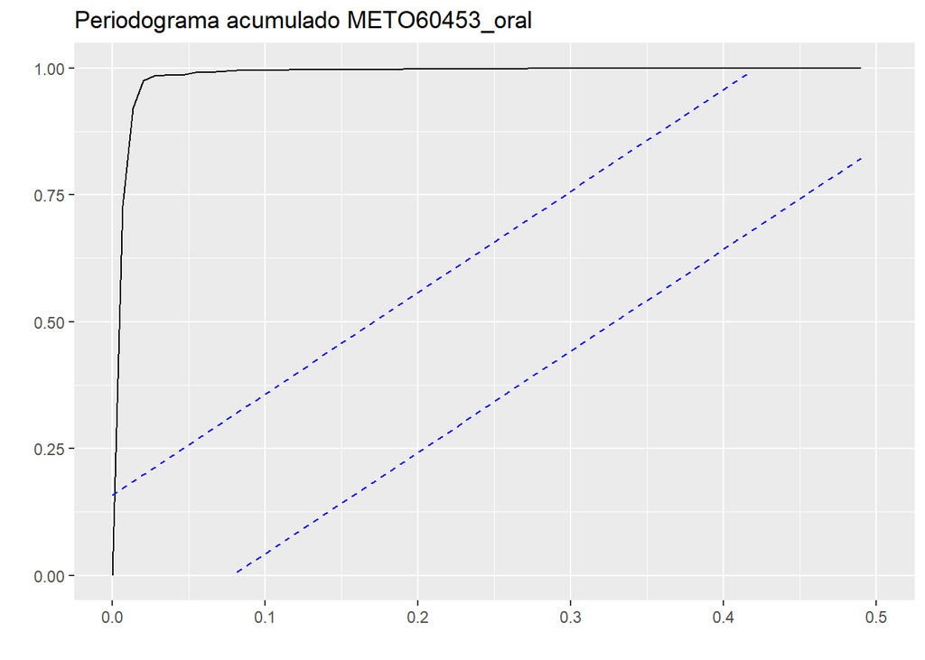

[2 more figures not shown]

Os periodogramas acumulados de pacientes de todos os medicamentos apontam para a existência de componente sistemático a ser modelado. Exceto para baricitinibe.

```r
meds %>%
  as_tibble() %>%
  group_by(key) %>%
  summarise(inicio = min(ano_mes),
            final = max(ano_mes),
            total_meses = n())
```

```
## # A tibble: 14 × 4
##    key                     inicio    final total_meses
##    <chr>                    <mth>    <mth>       <int>
##  1 ABAT60432_intravenoso 2013 abr 2022 mai         110
##  2 ABAT60432_subcutaneo  2016 set 2022 mai          69
##  3 ADAL60438_subcutaneo  2010 mar 2022 mai         147
##  4 BAMGPOCO60432_oral    2021 out 2022 mai           8
##  5 CERT60438_subcutaneo  2013 ago 2022 mai         106
##  6 CITR60432_oral        2018 out 2022 mai          44
##  7 ETAN60438_subcutaneo  2010 mar 2022 mai         147
##  8 GOLI60438_subcutaneo  2013 jul 2022 mai         107
##  9 INFL60438_intravenoso 2010 mar 2022 mai         147
## 10 LEFL60432_oral        2010 mar 2022 mai         147
## 11 METO60453_intravenoso 2010 mar 2022 mai         147
## 12 METO60453_oral        2010 mar 2022 mai         147
## 13 RITU60468_intravenoso 2013 abr 2022 mai         110
## 14 TOCI60469_intravenoso 2013 abr 2022 mai         110
```

Percebe-se que baricitinibe não tem observações suficientes para uma modelagem com os métodos de séries temporais. Dessa forma, este medicamento ficará de fora das análises por hora.